# Basic example of sexual debut simulation

Kinh Nguyen

2019-03-19

This vignette develops the workflow for simulating the EPP-ASM model with sexual debut.

Sexual debut model has the following extra movements

- Base population in the sexual debut age range is inititated as inactive and then move to active based on the debut probability.
- Entrant population enters the model as sexual inactive and then moves to sexual active with the debut probability.
- There are separete HIV and ART pop for sexual inactive group, these also move from inactive to active.
- HIV and ART pop is splitted to single year in the debut age range, the older age-groups (max debut age + 1) are grouped as the original age-group but with new group indices.
- Incidence calculation ignores the inactive population (including those in HIV positive with and without treatment).
- Core population, HIV population, and ART population are assigned as their own class (`refClasses.R`).

## Preparing EPP-ASM inputs

```r
# Use Botswana for convinient
pjnz <- system.file("extdata/testpjnz", "Botswana2018.PJNZ", package="eppasm")
bw <- prepare_spec_fit(pjnz, proj.end=2021.5)
```

### EPP model with single set of parameter inputs

Prepare model parameters from parameter vector input

```r
theta_ur <- c(-0.63758, -2.76655, -1.26204, 1996.65945, 0.00778, 0.05195,
              0.05103, 0.032, 0.01765, 0.01154, -0.00028, 0.01627, -0.00051,
              0.01439, -0.00937, -0.01135, 0.03692, 0.14959, 0.00803, 0.02424,
              -0.03548, 3.65223, -0.02515, -4.74563, 0.26259, -6.90124, 0.01583)

fp <- attr(bw$Urban, "specfp")
fp <- prepare_rhybrid(fp, rw_start = 2005, rw_dk = 1)

## Set some flags that are set in fitmod(), (later improve this code...)
fp$ancsitedata <- TRUE
fp$ancrt <- "both"
fp$logitiota <- TRUE
fp$rw_start <- 2005
fp$incidmod <- "eppspectrum"

param <- fnCreateParam(theta_ur, fp)
fp_par <- update(fp, list = param)
```

Blindly fix some wrong inputs

```r
# CD4 mortality rate > 1
fp_par$cd4_mort %>% range
```

```
#> [1] 0.004 1.851
```

```r
fp_par$cd4_mort %<>% `/`(max(fp_par$cd4_mort))
# Target pop < 0
negid <- fp_par$targetpop %>% {which(. < 0, TRUE)} %T>% {cat(fp_par$targetpop[.])}
```

```
#> -0.5549448 -3.185975 -0.8373995 -0.148923 -8.065678 -2.735333 -0.7257522 -14.41378 -5.400845 -1.083178 -17.68003 -7.460854 -1.018574 -15.2792 -7.824691 -0.5292683 -12.43119 -7.16555 -10.14485 -5.928921 -8.026182 -4.145966 -5.24344 -1.225679 -0.9085265
```

```r
fp_par$targetpop[negid] %<>% '*'(-1)
```

Simulate the model

### C++ version of the current model

```r
mod <- simmod(fp_par)
```

### R version of the current model

```r
modR <- simmod(fp_par, VERSION = "R")

expect_equal(prev(mod), prev(modR))
expect_equal(incid(mod), incid(modR))
```

## Demographic model (R only)

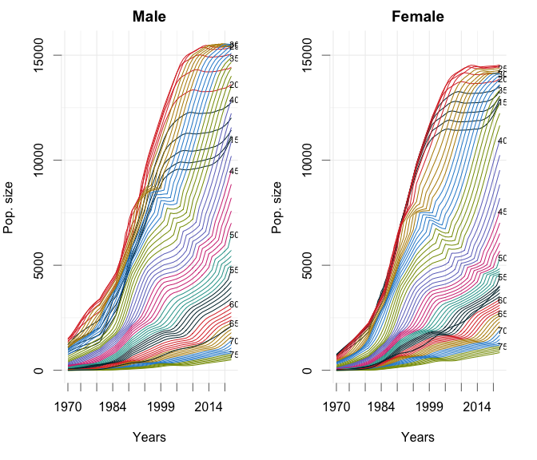

Figure: Demographic only

```r
demR <- simmod(fp_par, VERSION = "R", 0)
plot(demR)
```

## Sexual debut (R only)

How to run:

- update fp with debut probability matrix (add parameters and indices):
  - if data by age-group (`single_year=FALSE`, default):
    - 4 columns by order: male, female, lower age, upper age
  - if data by single-age (`single_year=TRUE`):
    - 4 columns by order: male, female, age male, age female
- specify `VERSION="R"` and `.MODEL=2`

### Test

That the model with 100% debut probability should be similar with model without debut:

```r
# All debut
db1 <- eppasm:::debut_pr
db1[, 1:2] <- 1

fp_db1 <- update_fp_debut(fp_par, db1)
modUni <- simmod(fp_db1, "R", 2)
```

Not exactly, only visually

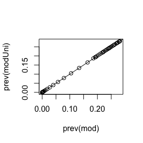

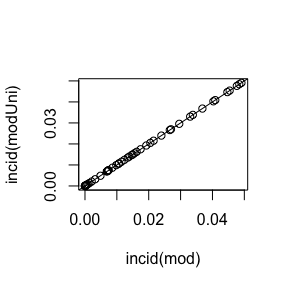

```r
plot(prev(mod), prev(modUni)); abline(0,1)
plot(incid(mod), incid(modUni)); abline(0,1)
```

## Simulation scenarios

### By age-group (Johnson et al. 2009)

Table: Name

| male | female | age_lo | age_up |
| --- | --- | --- | --- |
| 0.01 | 0.05 | 10 | 14 |
| 0.27 | 0.52 | 15 | 19 |
| 0.82 | 0.91 | 20 | 24 |
| 1.00 | 1.00 | 25 | 29 |

```r
fp_js <- update_fp_debut(fp_par, eppasm:::debut_pr)
modjs <- simmod(fp_js, VERSION = "R", 2)
```

### By single-year pr up to 17 (Cavazos-Rehg et al. 2009, Tab. 2, African-American)

Assume all debut at 18

```r
debut_cv <- rbind(debut_cv, c(1, 1, 18, 18))
```

Table: Cavazos-Rehg et al. (2009)

| 0.15 | 0.03 | 12 | 12 |
| --- | --- | --- | --- |
| 0.28 | 0.08 | 13 | 13 |
| 0.42 | 0.17 | 14 | 14 |
| 0.58 | 0.34 | 15 | 15 |
| 0.72 | 0.55 | 16 | 16 |
| 0.82 | 0.74 | 17 | 17 |
| 1.00 | 1.00 | 18 | 18 |

```r
fp_db_cv <- update_fp_debut(fp_par, debut_cv, NULL, single_year=TRUE)
modcv <- simmod(fp_db_cv, "R", 2)
```

### DHS data (Zimbabwe as an example)

Smooth and step-wise

```r
# devtools::install_github("ropensci/rdhs")
library(rdhs)

indicators <- dhs_indicators()
first_sex  <- grep('first sex', indicators[,"Definition"])
first_sex  <- first_sex[1:10]
myid       <- indicators[first_sex, "IndicatorId"]

ccc <- dhs_countries(returnFields=c("CountryName","DHS_CountryCode"))
zcc <- ccc[grep("Zimbabwe", ccc[, 2]), 1]

fsex <- dhs_data(countryIds = zcc, indicatorIds = myid, breakdown="all") %$%
        cbind.data.frame(perc=Value, agr=CharacteristicLabel, year=SurveyYear,
                         id=IndicatorId) %>%
        .[-grep("Total", .[, "agr"]), ] %>%
        subset(year==2015)

fsex$sex <- substring(fsex$id, nchar(as.character(fsex$id))-4,
                      nchar(as.character(fsex$id))-4) %>% factor %>% as.numeric
fsex$age <- substring(fsex$id, nchar(as.character(fsex$id))-1,
                          nchar(as.character(fsex$id))) %>% as.numeric

M_sm <- fsex %>% subset(sex==1) %$% smooth.spline(age, perc) %>% predict(15:30)
W_sm <- fsex %>% subset(sex==2) %$% smooth.spline(age, perc) %>% predict(15:30)
M_cs <- fsex %>% subset(sex==1) %$% approx(age, perc, 15:30, "constant")
W_cs <- fsex %>% subset(sex==2) %$% approx(age, perc, 15:30, "constant")

# Extrapolate to 30 when all are sexual experienced (debut probability = 1 in 30)
M_sm$y[M_sm$y > 100] <- 100
W_sm$y[W_sm$y > 100] <- 100
M_cs$y[is.na(M_cs$y)] <- max(M_cs$y, na.rm=TRUE)
W_cs$y[is.na(W_cs$y)] <- max(W_cs$y, na.rm=TRUE)
W_cs$y[length(W_cs$y)] <- 100
M_cs$y[length(M_cs$y)] <- 100
```

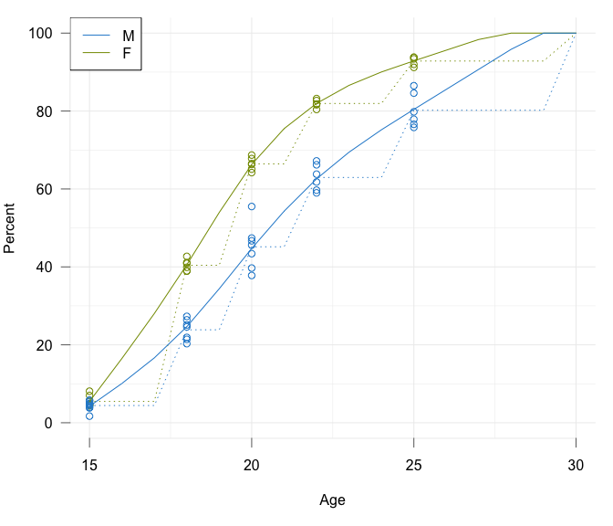

Figure: Probability of sexual debut

Update parameters and run

```r
# Smooth data
fp_sm  <- update_fp_debut(fp_par, zim_sm, single_year=TRUE)
mod_sm <- simmod(fp_sm, "R", 2)
# Step-wise data
fp_cs <- update_fp_debut(fp_par, zim_cs, single_year=TRUE)
mod_cs <- simmod(fp_cs, "R", 2)
```

## Outputs

- `output$data` is the same as the old `output`
- all attributes are stored as fields and accessed directly by `$`, with the same names.

### Prevalence by models

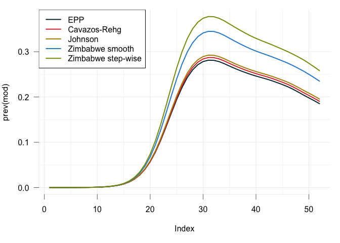

Figure: Prevalence 15-49

### Prevalence by ages

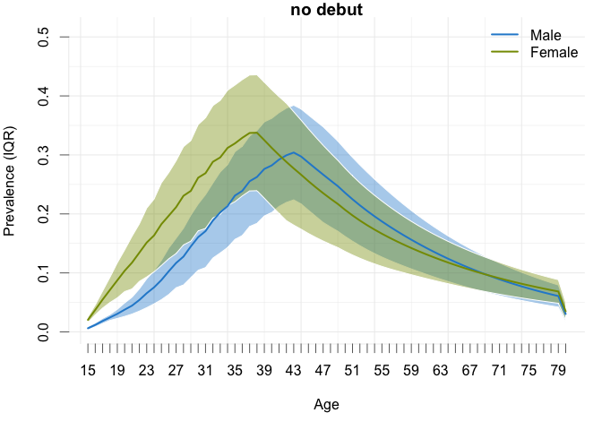

Figure: Prevalence by ages (no debut)

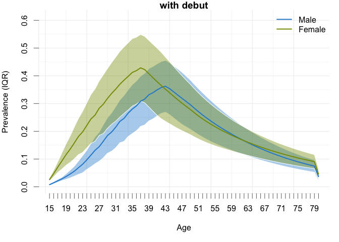

Figure: Prevalence by ages (Zimbabwe smooth)

### Prevalence by age over time

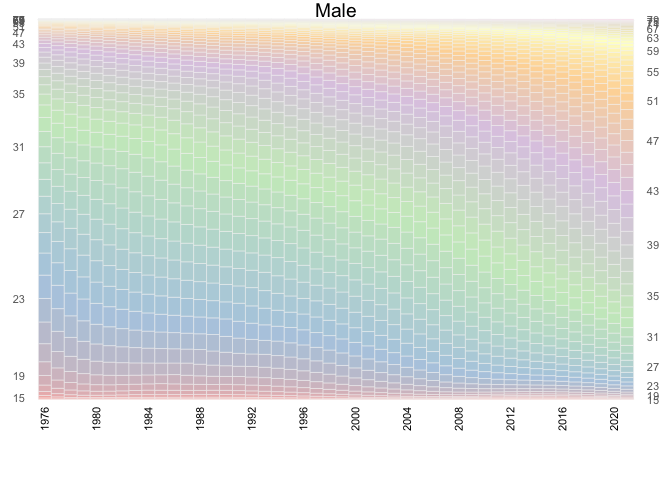

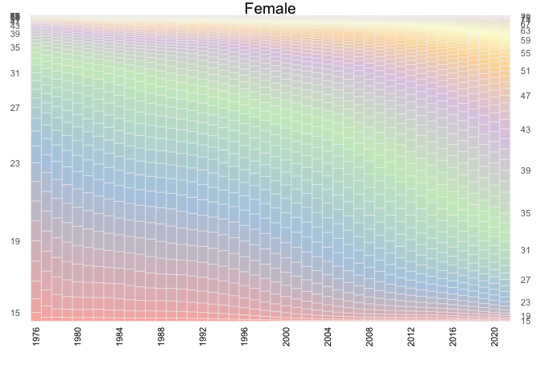

## References

Cavazos-Rehg, Patricia A, Melissa J Krauss, Edward L Spitznagel, Mario Schootman, Kathleen K Bucholz, Jeffrey F Peipert, Vetta Sanders-Thompson, Linda B Cottler, and Laura Jean Bierut. 2009. “Age of sexual debut among US adolescents.” *Contraception* 80 (2): 158–62.

Johnson, Leigh, Rob Dorrington, Debbie Bradshaw, Victoria Pillay-Van Wyk, and Thomas Rehle. 2009. “Sexual behaviour patterns in South Africa and their association with the spread of HIV: insights from a mathematical model.” *Demographic Research* 21 (July): 289–340.